# PROYECTO -Pg2

2 de septiembre 2022

# **Importación de datos en formato csv**

## Carga de librerías

Leer las librerías

```r
library(lubridate)
library(ggthemes)
library(tidyverse)
library(car)
```

```r
library(readr)
library(dplyr)
library(boxplotdbl)
library(ggplot2)
library(DescTools)
```

#INTRODUCCIÓN ## Relevancia O Justificación

AL pasar más tiempo en un videojuego, existo una relación con el rendimiento académico, Por ello, el estudio es de mucho interés para un estudiante, Esta información le será de mucha utilidad a estudios de métodos de estudio, para dar obtener probabilidades ya que podremos obtener datos del rendimiento o promedio académico de un alumno en función del tiempo que este dedica a los videojuegos, además que otras variables están muy asociadas al rendimiento académico. ## Objetivos

### Objetivo general

Determinar si el tiempo que un estudiante le dedica a los videojuegos de las principales empresas de videojuegos tienen relación con el rendimiento académico del estudiante del periodo académico 2022-2 de la UTEC.

### Objetivos específicos

- determinar si el tiempo jugado es un factor en el rendimiento académico de los estudiantes
- Encontrar el tipo de relación entre el tiempo jugado y el rendimiento académico de los estudiantes
- Encontrar una función para determinar el promedio de un estudiante a partir del tiempo jugado
- Determinar si hay factores que intervienen en el bajo rendimiento académico de los estudiantes.
- Analizar el promedio académico según las horas jugadas.
- determinar la probabilidad de que un alumno desapruebe uno o más cursos al pasar más horas jugando en el juego
- Determinar sobre nuestras variables aleatorias discretas y a qué modelo, binomial, binomial negativa, geométrica, etc.
- determinar la probabilidad de que una persona duerma más o menos al pasar más horas jugando.

## PLANIFICACION:

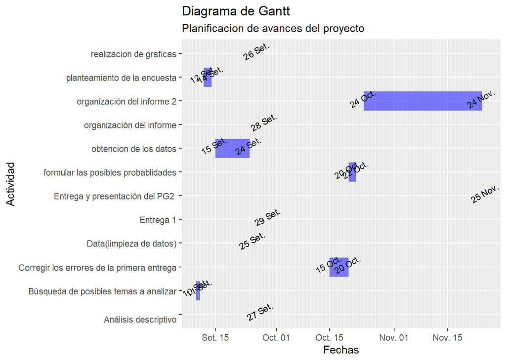

# Descripción del Proyecto

# introducción

## Proceso de recolección de datos

El proceso de recolección de datos se desarrolló por medio de una encuesta vía google forms, ya que consideramos que era el mejor medio para llevar a cabo una encuesta de satisfacción, debido a que nos permite asignar preguntas de opción múltiple, además de permitirnos tener toda la información organizada en hojas de cálculo de Excel. Para poder llegar a nuestra población objetivo, procuramos enviar el link de la encuesta a grupos conformados por estudiantes de UTEC mediante las redes sociales.

### POBLACIÓN, MUESTRA Y MUESTREO

-**población**: Estudiantes de la Universidad de Ingeniería y Tecnología - UTEC. 2022-2.

-**muestra**: los 202 estudiantes de la UTEC que están en el semestre académico 2022-2.

-**Unidad muestral**:un estudiante de la UTEC del semestre academico 2022-2..

-**Diseño de investigación** :la muestra es representativa, dado que se la encuesta de hizo de forma aleatoria , el tipo de muestreo es por probabilística porque fue lanzada por las redes sociales y el que podía lo completada (fue la opción más viable para recolectar los datos).

## Variables

**Variables cuantitativas:**

- **“Edad”**: Esta medido en la cantidad de años que tiene el estudiante. Es una variable numérica discreta. **Restricción:** No puede ser negativo ya que toman valores enteros.
- **Dinero**: Está medido en cantidad de dinero que gasta al año. Es una variable numérica continua. **Restricción:** No puede ser negativo .
- **cursoxciclo**: Esta medido en la cantidad de curso que lleva un estudiante. Es una variable numérica discreta. **Restricción:** No puede ser negativo ya que toman valores enteros.
- **promedio**: Está medido en la cantidad del promedio general que obtiene en un ciclo. Es una variable continua. discreta. **Restricción:** No puede ser negativo
- **Horasdormidas**: Está medido en la horas dormidas en un día. Es una variable aleatoria continua. **Restricción:** No puede ser negativo.
- **Cursodesaprobado**: Mide la cantidad de cursos desaprobados.Es una variable numérica discreta. **Restricción:** No puede ser negativo.

**Variables Categóricas:**

- **Juegas**: Es una variable binaria porque solo puede tomar los siguientes valores de *“Si”* y *“no*.
- **Genero** : Es una variable binaria porque solo puede tomar los valores de ‘masculino’ o ‘femenino’,.
- **Plataforma**: Esta unidad representa en que plataforma juega.
- **GameMode**: Esta unidad representa en que modo de juego juega
- **GameValor**: Esta unidad nos muestra que le gusta mas de los videojuegos.
- **CompaniaGames*: Esta unidad nos muestra de que compañía le gusta mas de los videojuegos.
- **Cicloactual*:Es una variable binaria porque solo puede tomar los siguientes valores de* “Si”* y *“no*.

## Limpieza de Datos

En estas sección lo que haremos es hacer que la data que nos sera de utilidad, asimismo nos facilitara la interpretación y el trabajo. Por lo que haremos uso de R studio, en donde corregiremos los datos que no tienen sentido , las respuestas mas escritas , para Ello haremos diversos pasos que se realizaran a continuación.

## Carga de datos

[output not shown]

```
##  [1] "Marca temporal"
##  [2] "¿Juegas videojuegos?"
##  [3] "Género"
##  [4] "Edad"
##  [5] "Carrera"
##  [6] "¿Qué manera de jugar te gusta más?"
##  [7] "¿Prefieres juegos multiplayer o singleplayer?"
##  [8] "¿Qué valoras más en un videojuego?"
##  [9] "Plataforma en la que juega:"
## [10] "Tiempo que dedica a jugar videojuegos\nEjem: 1 hora a la semana"
## [11] "¿Qué género de videojuego prefieres?"
## [12] "¿Qué compania crees que tiene mejores juegos?"
## [13] "Cantidad de dinero que gastas en video juegos en un año"
## [14] "¿Cuántos cursos estas llevando en el ciclo?"
## [15] "¿Cual es tu promedio ponderado?\nValor comprendido entre 1 a 20. \nEjm: 14.67"
## [16] "¿Cuantas horas al dia duermes?\nEjm: 4"
## [17] "¿Cuantos cursos desaprobados tienes?"
## [18] "Sigues los cursos que corresponden a tu ciclo actual. ¿Si o no?"
## [19] "¿Por qué no te gustan los videojuegos?"
```

**Cambio de nombre a las variables**

En esta sección cambiaremos los variables par que sea mas fácil trabajar al momento de acceder a una informacion de la data.

#Limpieza de datos NO juegan

Como en nuestro caso de estudio es sobre los alumnos que juegan videojuegos filtraremos en un archivo llamado *GameSi* solo a los alumnos que juegan.

[output not shown]

```
## [1] "1"       "2"       "Ninguno" "3"       "4"       "6"       "5"
## [8] "8"
```

| cursodesaprobado | n |
| --- | --- |
| 0 | 112 |
| 1 | 36 |
| 2 | 19 |
| 3 | 9 |
| 4 | 3 |
| 5 | 2 |
| 6 | 2 |
| 8 | 1 |

```
##  [1] "Marca temporal"   "Género"           "Edad"             "Carrera"
##  [5] "juegas"           "Plataforma"       "GameMorS"         "GameMode"
##  [9] "GameValor"        "Tiempo"           "GeneroGames"      "CompaniaGames"
## [13] "Dinero"           "cursoxciclo"      "promedio"         "horasdormidas"
## [17] "cursodesaprobado" "cicloactual"
```

#ANÁLISIS DESCRIPTIVO

#Analizr si existen los valores de datos atipicos en la base de datos ### 6.1 Boxplot Varible edad

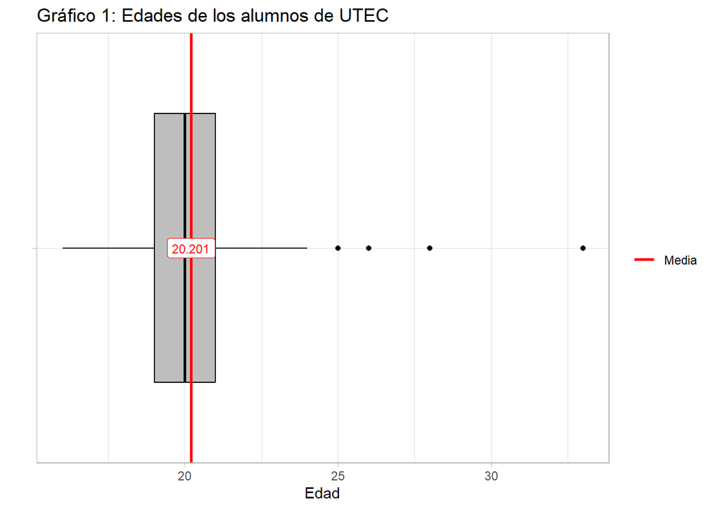

En este diagrama de cajas para la variable edad podemos visualizar una concentración de datos alrededor de la mediana ,donde la media que es igual 20 años, ademas se observa una distribución asimétrica con presencia de datos atípicos, donde la media ya no es representativa, ademas presenta un sesgo positivo.

### 6.2 Boxplot Varible Horas de videojuegos

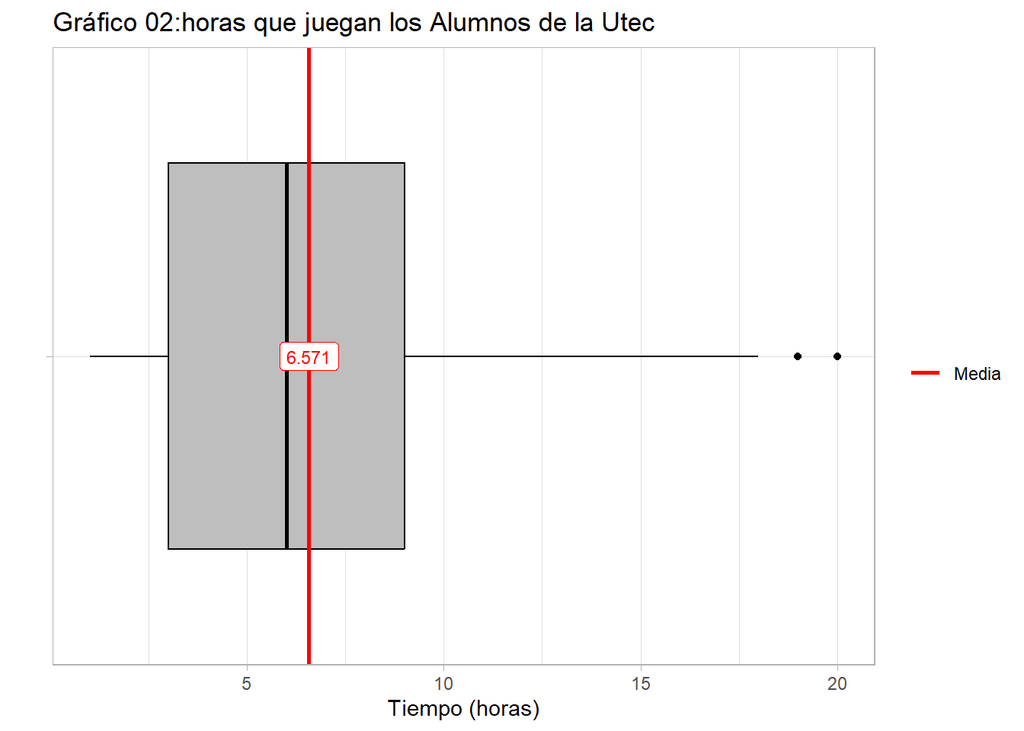

```
## $stats
## [1]  1  3  6  9 18
##
## $n
## [1] 184
##
## $conf
## [1] 5.301125 6.698875
##
## $out
## [1] 20 19
```

En este diagrama de cajas para la variable tiempo podemos visualizar una concentración de datos alrededor de la mediana ,donde la media que es igual 6.571 horas , ademas se observa una distribución asimétrica con presencia de datos atípicos, donde la media ya no es representativa, ademas presenta un sesgo positivo .

### 6.3 Boxplot Varible Horas de dormido

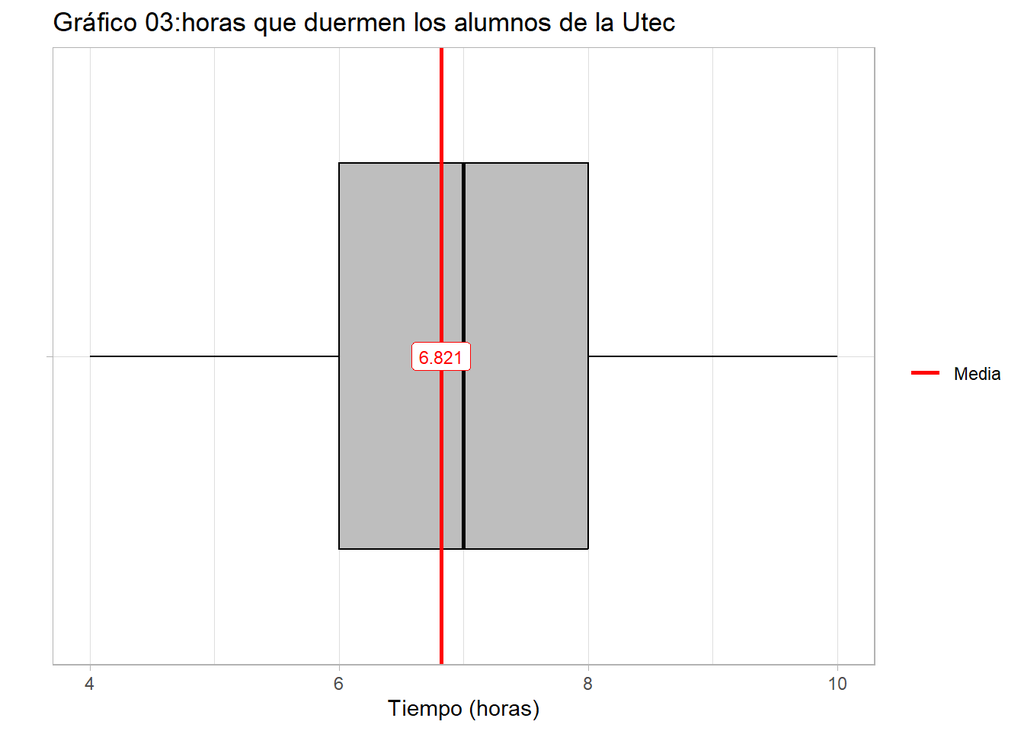

```
## $stats
## [1]  4  6  7  8 10
##
## $n
## [1] 184
##
## $conf
## [1] 6.767042 7.232958
##
## $out
## numeric(0)
```

En este diagrama de cajas para la variable horasdormido podemos visualizar una concentración de datos alrededor de la mediana ,donde la media que es igual 6.821 horas , ademas se observa una distribución casi simétrica y no hay atípicos, done la media es representativa. ### 6.4 Boxplot de la variable promedio ponderado

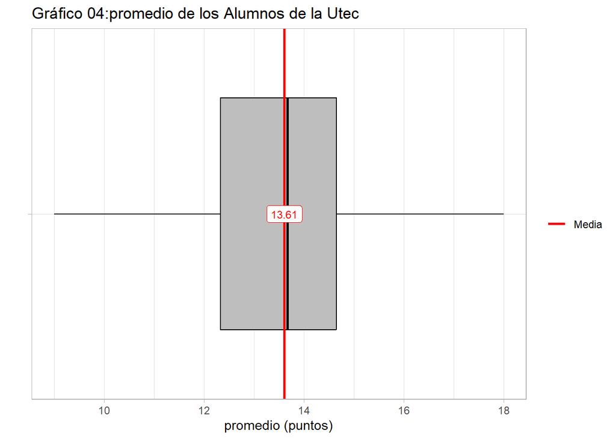

```
## $stats
## [1]  9.000 12.330 13.675 14.650 18.000
##
## $n
## [1] 184
##
## $conf
## [1] 13.40477 13.94523
##
## $out
## numeric(0)
```

En este diagrama de cajas para la variable promedio podemos visualizar una concentración de datos alrededor de la mediana ,donde la media que es igual 13.61 puntos , ademas se observa una distribución casi simétrica y no hay atípicos, done la media es representativa

### 6.5 Boxplot de la variable dinero x juego

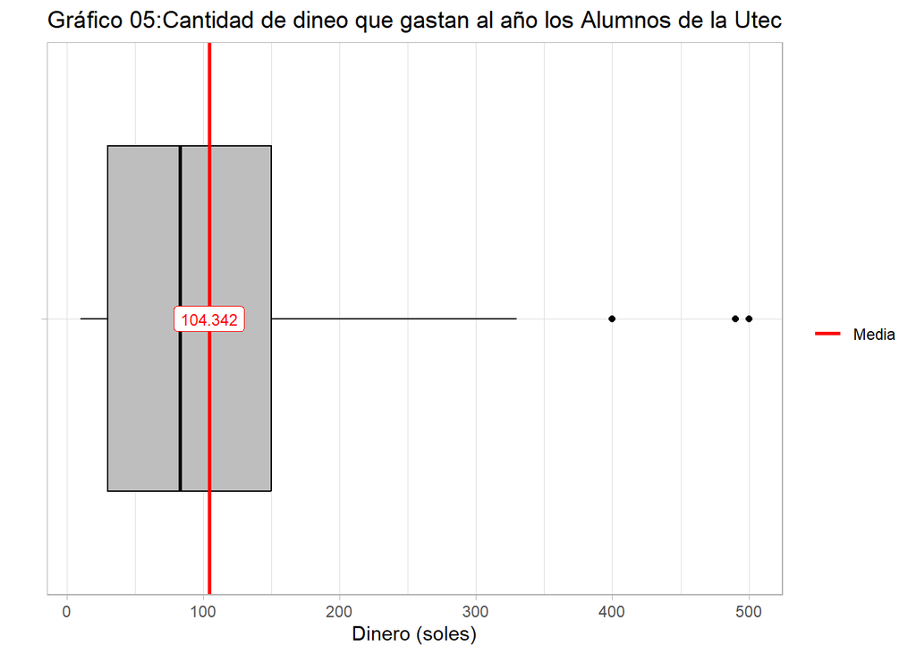

```
## $stats
## [1]  10  30  83 150 330
##
## $n
## [1] 184
##
## $conf
## [1] 69.0225 96.9775
##
## $out
## [1] 500 490 400
```

En este diagrama de cajas para la variable dinero podemos visualizar una concentración de datos alrededor de la mediana ,donde la media que es igual 104.342 soles , ademas se observa una distribución asimétrica con presencia de datos atípicos, donde la mediana es representativa, ademas el coeficiente de asimetria es positivo .

### 6.3 Boxplot de la variable curso x ciclo

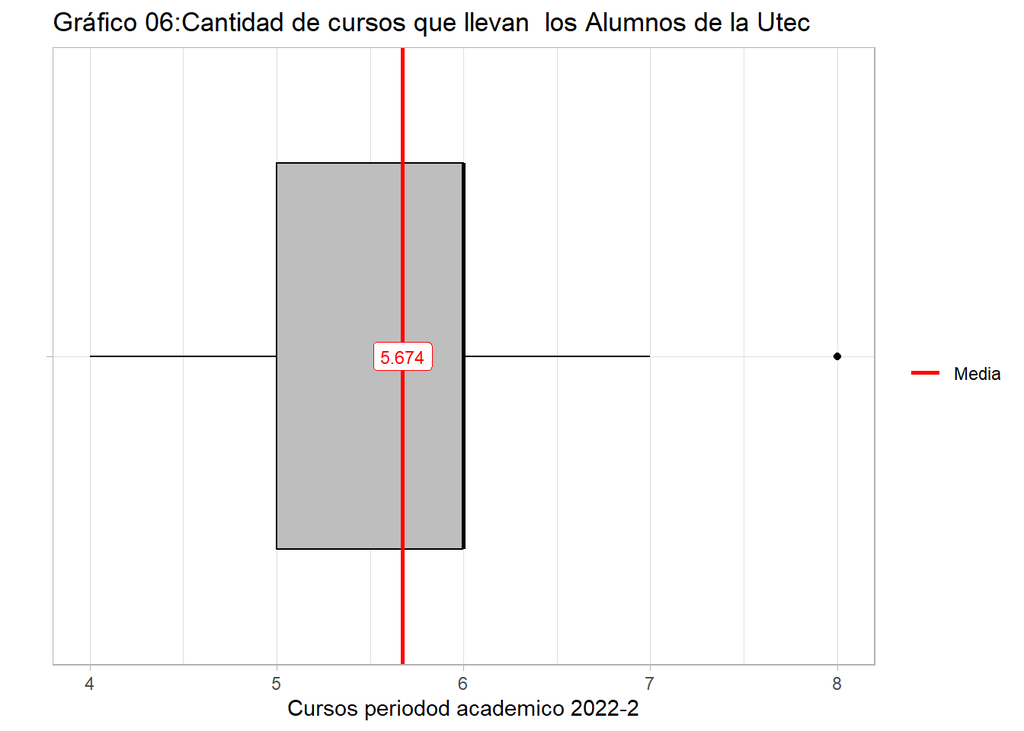

```
## $stats
## [1] 4 5 6 6 7
##
## $n
## [1] 184
##
## $conf
## [1] 5.883521 6.116479
##
## $out
## [1] 8 8 8 8 8 8 8
```

##descriptores numericos

### Analisis de la variable promedio de notas

#### media, mediana y moda

```
## [1] 13.61005
```

```
## [1] 13.675
```

```
## [1] 14.23
## attr(,"freq")
## [1] 9
```

El promedio de las notas es 13,61 La mitad de los alumno con menos promedio tiene una nota máxima de 13,68 La moda del promedio ponderado es 14.23, con 9 repeticiones #### Cauntil q%

```
##   10%
## 11.34
```

```
## 90%
##  16
```

El 10% de los alumnos con menos notas tienen una nota máxima de 11, 34 El 10% de los alumnos con mayores notas tienen una nota mínima de 16

#### Rango intercuartil de la variable Promedio:

```
## [1] 2.315
```

EL rango intercuartil de la variable promedio promedio es de 2.32 puntos.

#### Desviación estandar

```
## [1] 1.872549
```

```
## [1] 3.506439
```

La variabilidad del promedio de notas es de 1.87 puntos la variabilidad del promedio de notas de notas es 3.51 puntos cuadrados.

### Análisis variable Tiempo(horas que juegan)

#### mediana,media y moda

```
## [1] 6.570652
```

```
## [1] 6
```

```
## [1] 6
## attr(,"freq")
## [1] 27
```

El promedio del tiempo en horas jugado es 6.570652 horas . La mitad de los alumno que menos juegan , juegan 6 horas. La moda de las horas jugadas es 6 con 27 repeticiones.

#### Cauntil q%

```
## 10%
##   1
```

```
## 90%
##  13
```

El 10% de los alumnos que juegan menos, jeugan 1 hora. El 10% de los alumnos que juegan más , juegan 13 horas. #### Rango intercuartil de la variable :

```
## [1] 6
```

EL rango intercuartil de la variable tiempo 6.

#### Desviación estandar y varianza

```
## [1] 4.238183
```

```
## [1] 17.96219
```

La variabilidad del tiempo de notas es de 4.24 horas. la variabilidad del promedio de notas de notas es 17.96 horas cuadrado.

### analisis de la variable dinero

#### media, mediana y moda

```
## [1] 104.3424
```

```
## [1] 83
```

```
## [1] 100
## attr(,"freq")
## [1] 18
```

El promedio del dinero gastado al año es 104.34 soles . La mitad de los alumno que menos gastan, juegan 83 soles. La moda del dinero gastado es 100 con 18 repeticiones.

#### Cauntil q%

```
## 10%
##  12
```

```
##   90%
## 218.5
```

#### Rango intercuartil de la variable Promedio:

```
## [1] 120
```

EL rango intercuartil de la variable dinero es 120 soles.

#### Desviación estandar

```
## [1] 93.61319
```

```
## [1] 8763.429
```

La variabilidad del dinero gastado es de 93.62 soles. la variabilidad del dinero gastado es 8763.43 soles cuadrado.

## VII. Descriptores gráficos y tablas

Utilizando algunos gráficos estadísticos y tablas que nos permitirán sacar analisis y encontrar las respuestas a nuestro objetivo .

### 1. Analisis de la variable promedio

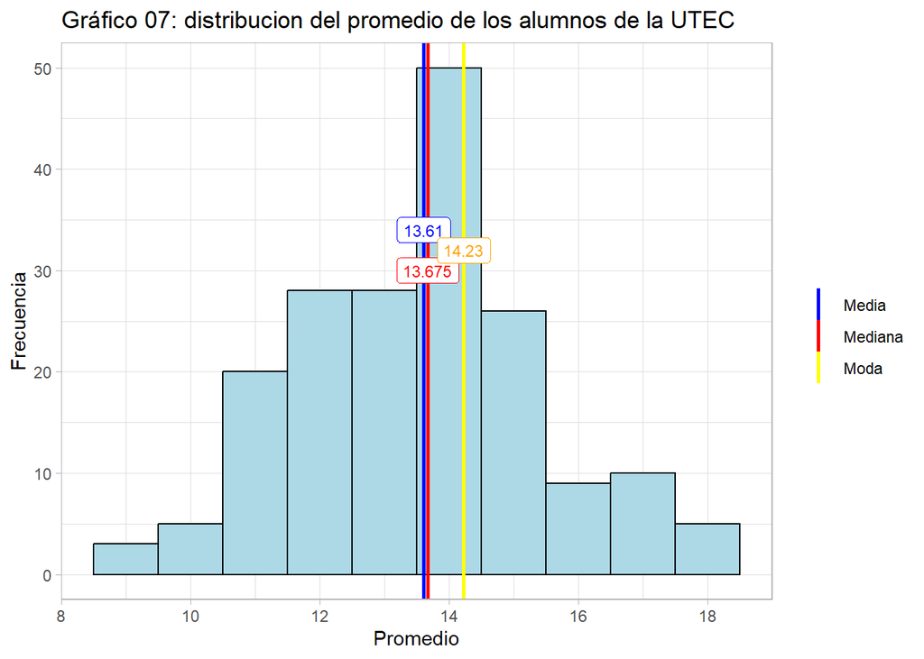

### proporcion de juego por genero con el ciclo actual

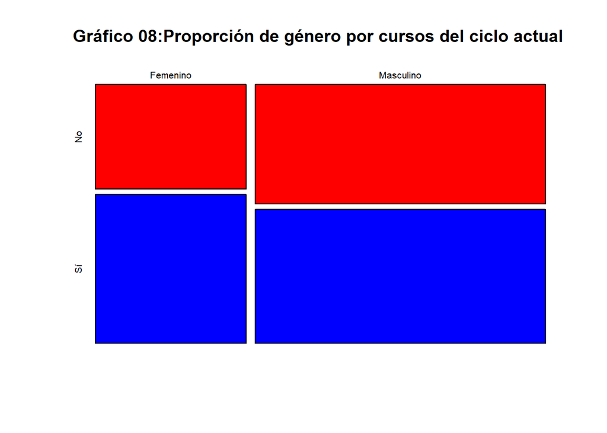

El gráfico de mosaico indexsado nos muestra una diferencia mínima de lo genero que si llevan los cursos correspondientes al ciclo actual,asimismo nos muestra que los hombres son los que juegan en mayor cantidad que las mujeres, sin embargo las mujeres son las que llevan los cursos correspondientes a su ciclo actual.

### 3. Determinar la cantidad de horas de juego por semana dependiendo el promedio

```
##  [1]  5 10  8  3  4  6  2 13  1  9 18 15  7 20 12 11 19 17 14
```

#### primer grafico (los priemeros 9 horas)

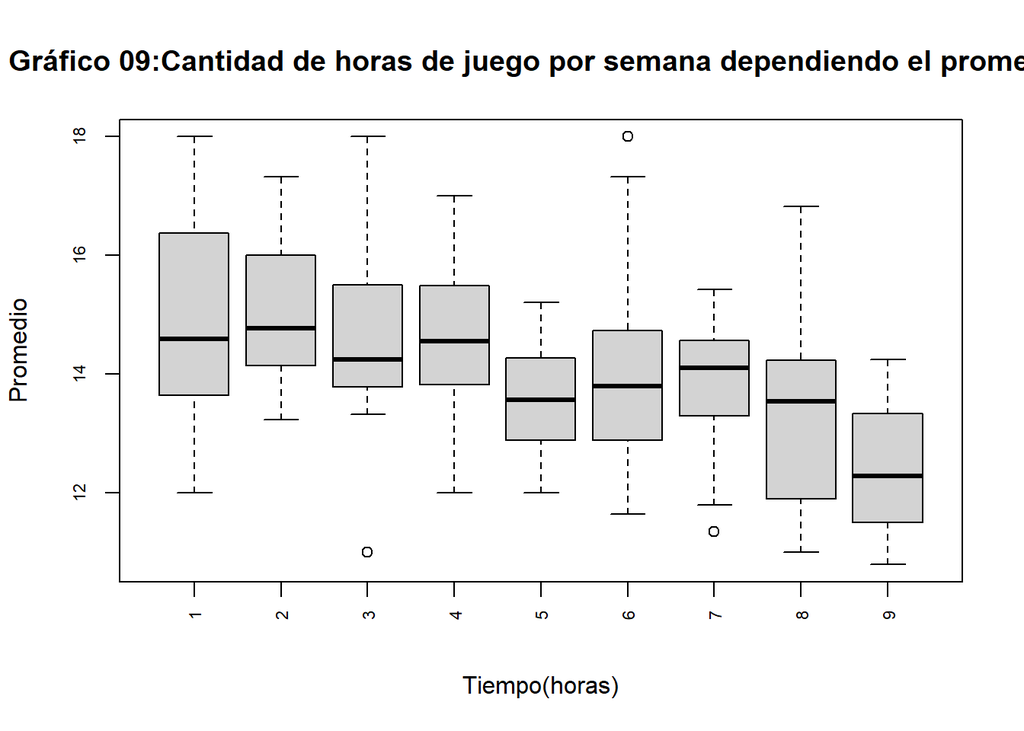

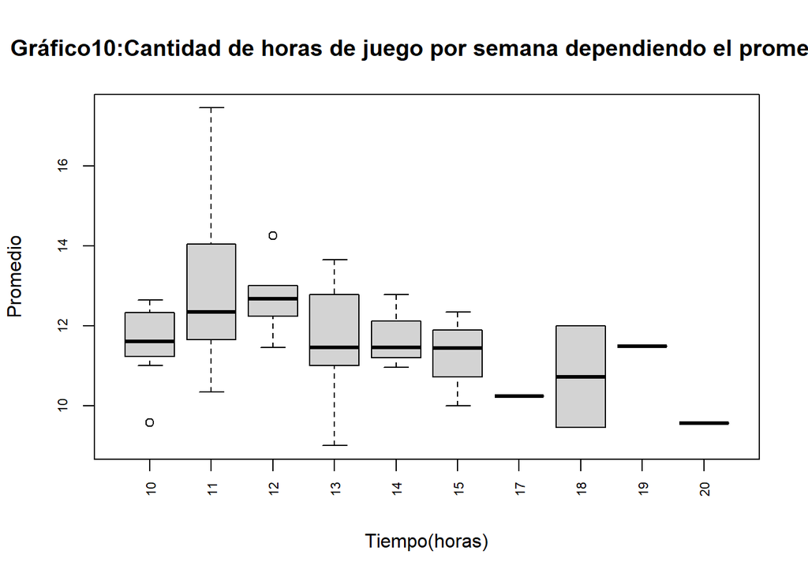

El gráfico es un boxplot indexado del promedio de notas por tiempo de juego , lo dividimos en dos para fines mejor interpretacion , con respecto al tiempo *tiempo1* y *tiempo2*, que están separados en los primeros 9 horas y mayores a 9 horas respectivamente. ,observando que le promedio de notas del estudiante es distinto por el tiempo de horas jugado.

### 4.Determinar la cantidad de personas que juegan videojuegos les gusta un genero de videojuego

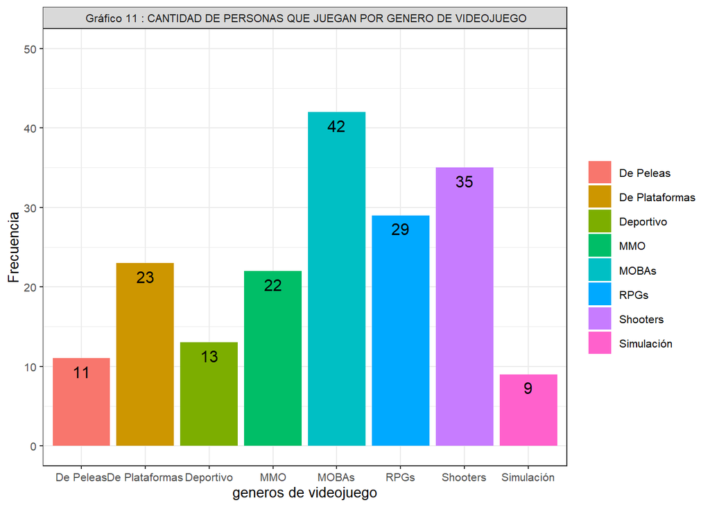

El gráfico de barras nos muestra una distribución del *genero de vidiojuego*, donde podemos apreciar que el tipo de juego MOBAs es el que mas juegan y la simulación la que menos juegan.

```
##
##                                Celular                       PC (Computadora)
##                                     24                                     50
## Play Station (PS1, PS2, PS3, PS4, PS5)                                 Switch
##                                     70                                     19
##    XBox (360, One, Series S, Series X)
##                                     21
```

En la tabla podemos observar que los estudiantes prefieren jugar en el *play station* y el *switch* prefieren en menor cantidad.

```
##
##          Activicion Blizzard (Call of Duty, World of Warecraft, Overwach, etc)
##                                                                             26
##                                   CD Projekt Red (The Witcher, Cyberpunk 2077)
##                                                                             12
##                                                        EA (FIFA, Mass Efect, )
##                                                                              5
##                        Epic Games (Fortnite, Rocket League, Gears of War, etc)
##                                                                             15
##                        From Software (Dark Souls, Bloodborne, Elden Ring, etc)
##                                                                              2
##                         Microsoft (Skyrim, Fallout, Minecraft, Halo, Starfild)
##                                                                             24
## Nintendo (Super Mario Bross, Mario Kart, Pokémon Rojo , Super Smash Bros, etc)
##                                                                             15
##          Play Station (The Last of Us, God of War, Horizon Forbiden West, etc)
##                                                                              9
##                       Riot Games (League of Legends, Valorant, Wild Rift, etc)
##                                                                             24
##              Square Enix (Finall Fantasy, Kindom Heards, Life is Strange, etc)
##                                                                             11
##                                           Valve (Dota, Half Life, Portal, etc)
##                                                                             32
##         Warner Bros (MultiVersus, Batman, Juegos de Lego, Back for Blood, etc)
##                                                                              9
```

```
##
##       Co-Op (Coperativo) PvE (Jugador VS Maquina) PvP (Jugador VS Jugador)
##                       26                       73                       85
```

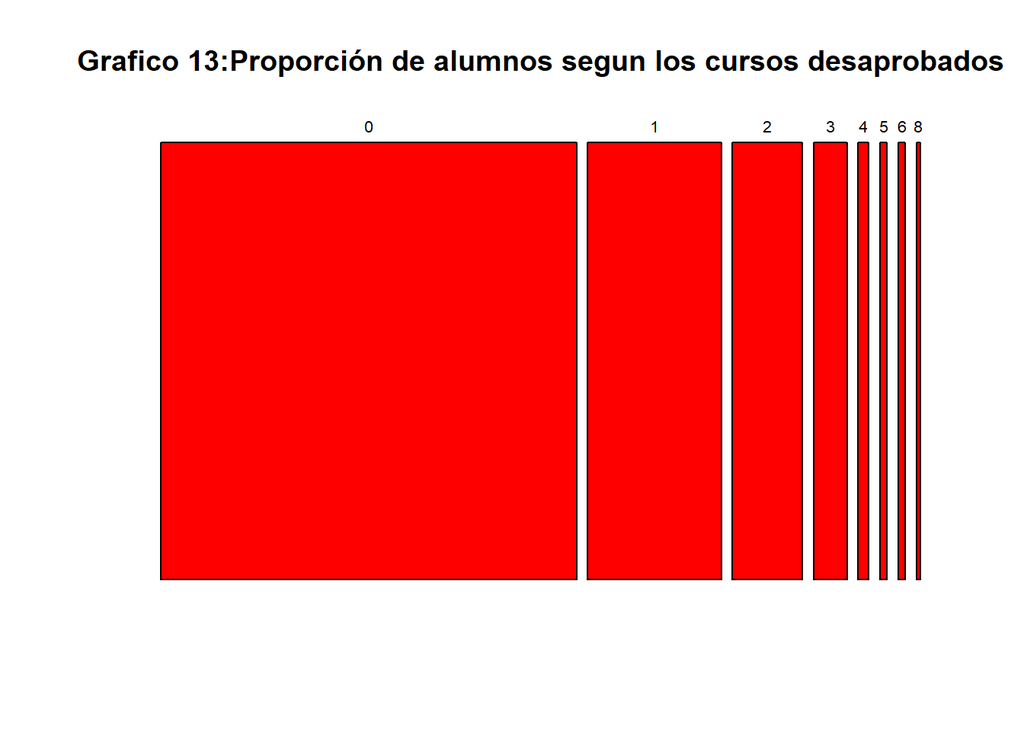

El gráfico de mosaico nos indica la proporción de la variable alumnosdesaprobados . Podemos observar que la ,ayoria no tienen cursos jalados, asimismo apreciamos que la cantidad de cursos se reduce.

## VIII. Regresión lineal

### 6.RL. Horas de juego X dinero invertido

```
## [1] 0.8822238
```

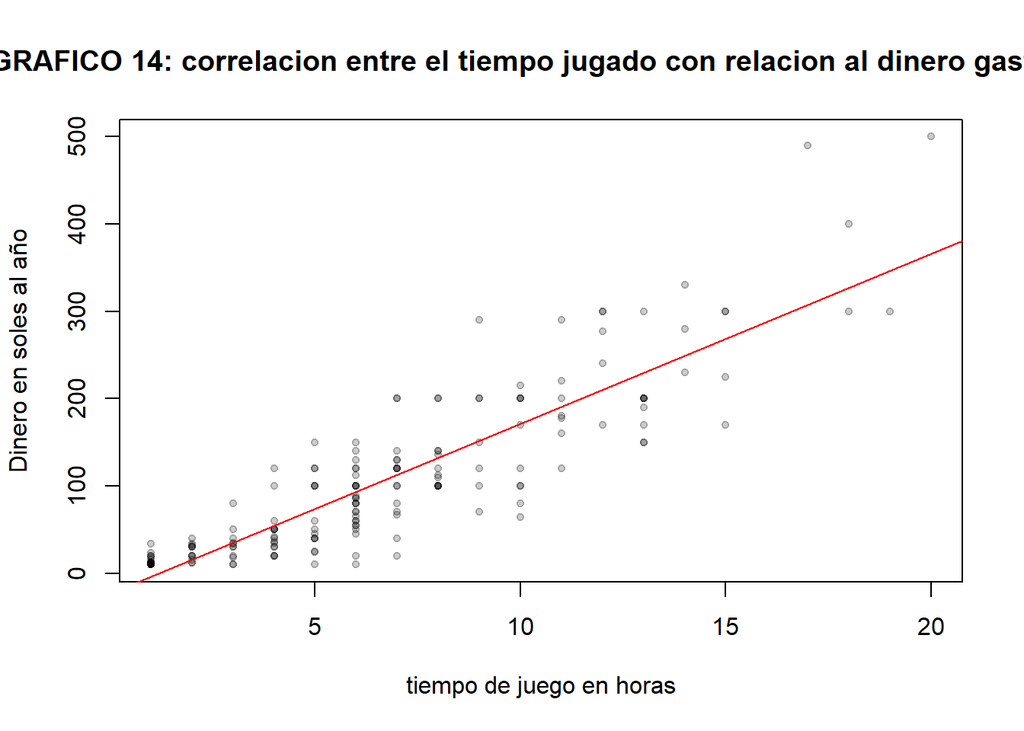

```
##
## Call:
## lm(formula = GameSi$Dinero ~ GameSi$Tiempo)
##
## Residuals:
##      Min       1Q   Median       3Q      Max
## -107.169  -29.629   -0.019   19.961  182.425
##
## Coefficients:
##               Estimate Std. Error t value Pr(>|t|)
## (Intercept)   -23.6973     6.0226  -3.935 0.000118 ***
## GameSi$Tiempo  19.4866     0.7709  25.278  < 2e-16 ***
## ---
## Signif. codes:  0 '***' 0.001 '**' 0.01 '*' 0.05 '.' 0.1 ' ' 1
##
## Residual standard error: 44.2 on 182 degrees of freedom
## Multiple R-squared:  0.7783, Adjusted R-squared:  0.7771
## F-statistic:   639 on 1 and 182 DF,  p-value: < 2.2e-16
```

En esta gráfica de dispersión nos muestra que existe una correlación lineal entre las horas jugadas a la semana con respecto al dinero gastado al año, asimismo podemos apreciar que cuando un alumno juega mas tiempo tiene una tendencia a gastar mas. De igual manera los que juegan menos gastan mucho menos, ademas el coeficiente de correlación linial entre variables es fuerte y positiva de valor igual a 0.8822238.

### Determinar la cantidad/densidad del promedio de los estudiantes según las horas de juego

```
## [1] -0.6093922
```

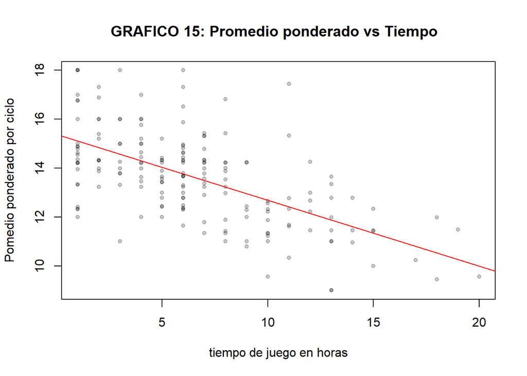

En esta grafica de dispersión podemos observar claramente que cuan un estudiante pasa mas horas jugando tiende a obtener un promedio bajo con relación al tiempo jugado.Esto se podría interpretar que al jugar mas tiempo dedican menos a estudiar y es mas probable que jale cursos,ademas el coeficiente de correlación linial entre variables es buena y negativa de valor igual -0.6093922.

.

### 7.Determinar la cantidad/densidad de personas atrasadas según las horas de juego

```
##
##       1  2  3  4  5  6  7  8  9 10 11 12 13 14 15 17 18 19 20
##   No  0  1  2  4  7 15  7  6  4  7  4  5  9  3  4  1  2  1  1
##   Sí 24 11  9 12  8 12  9  7  3  3  3  0  0  0  0  0  0  0  0
```

```
##
##                                        Femenino Masculino
##   Administración de Negocios Digitales        1         0
##   Bioingeniería                               6         9
##   Ciencia de Datos                            0         2
##   Ciencia de la Computación                   1         6
##   Ingeniería Ambiental                        5         5
##   Ingeniería Civil                           12        12
##   Ingeniería de la Energía                    2         7
##   Ingeniería Electrónica                      4        11
##   Ingeniería Industrial                      12        10
##   Ingeniería Mecánica                         8        17
##   Ingeniería Mecatrónica                      8        30
##   Ingeniería Química                          4        12
```

```
## [1] 121
```

```
## [1] 63
```

# PROBABILIDAD

## variable aleatoria discreta

### Análisis en base a la variable carrera

[figure not shown]

```
##
## Administración de Negocios Digitales                        Bioingeniería
##                                    1                                   15
##                     Ciencia de Datos            Ciencia de la Computación
##                                    2                                    7
##                 Ingeniería Ambiental                     Ingeniería Civil
##                                   10                                   24
##             Ingeniería de la Energía               Ingeniería Electrónica
##                                    9                                   15
##                Ingeniería Industrial                  Ingeniería Mecánica
##                                   22                                   25
##               Ingeniería Mecatrónica                   Ingeniería Química
##                                   38                                   16
```

```
## [1] 184
```

###Caso probabilistico para la variable aleatoria discreta carrera.

¿De un grupo de 20 alumnos que juegan videojuego cual es la probabilidad ?

1. que 5 sean de mecatrónica
2. mas de 5 sean de mecatrónica
3. que a lo mas 5 sean de mecatrónica

SOLUCION: Para sacar una probabilidad con respecto a la variable carrera según y responder el caso haremos uso de los conceptos de una probabilidad aleatoria discreta de de tipo binomial.
$$X∼Bin(x,n,p)$$

Sea la variable aleatoria:

X:numero de alumnos de la utec que juegan videojuegos que son de mecatrónica X tiene una distribución binomial con parámetros: n=20, p=38/184

```
## [1] 0.1812584
```

La probabilidad de que sean 5 alumnos de mecatrónica de un grupo de 20 alumnos es 0.1812584.

```
## [1] 0.2176457
```

La probabilidad de que sean mas de 5 mecatrónica de un grupo de 20 alumnos es 0.2176457.

```
## [1] 0.7823543
```

### Grafico de los que juegan por genero

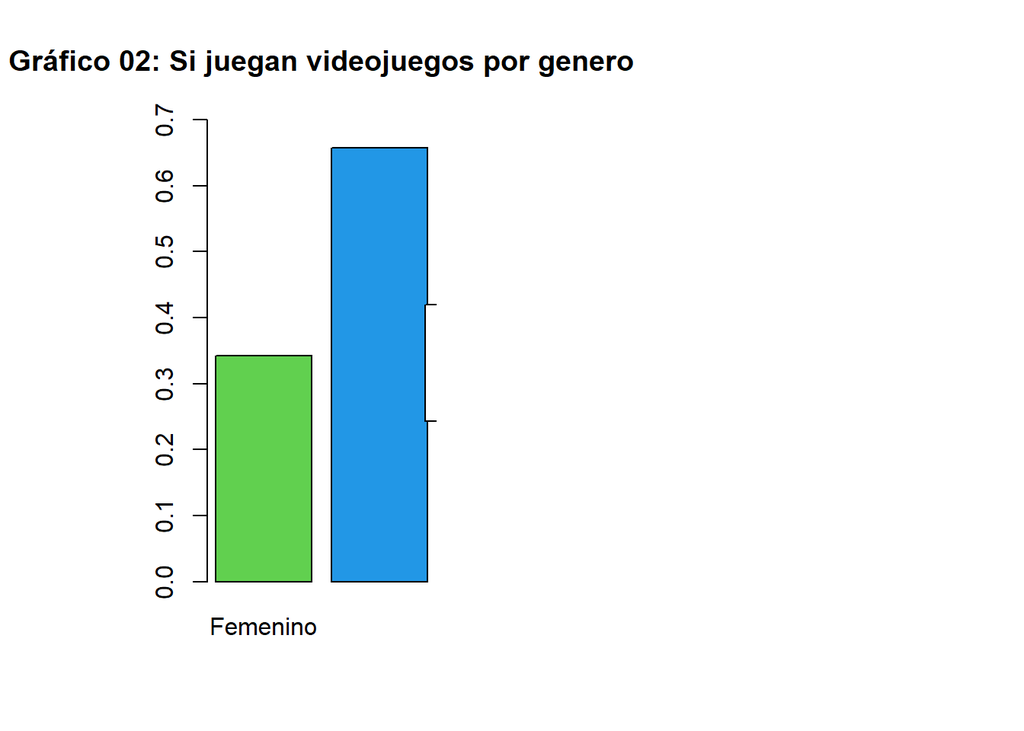

```
##
##  Femenino Masculino
##        63       121
```

```
## [1] 184
```

###Caso probabilistico para la variable aleatoria discreta género.

GEOMETRICA

En el auditorio aveces se reunión que juegan videojuegos y se observa el numero de personas que ingresan hasta la primera de género femenino, calcule la probabilidad A)de observar 5 personas B)de observar mas de 5 personas C) de observar a lo mas 5 personas SOLUCION

Sea la variable aleatoria:

X:numero de alumnos observados que ingresan al auditorio hasta encontrar una de genero femenino  
X tiene una distribución geométrica con parámetros: P=63/184

```
## [1] 0.06403139
```

La probabilidad de encontrar a 5 de género femenino en la reunión para jugar en el auditorio es: 0.06403139.

```
## [1] 0.1229809
```

La probabilidad de encontrar mas de 5 de género femenino en la reunión para jugar en el auditorio es: 0.1229809.

```
## [1] 0.8770191
```

La probabilidad de encontrar a lo mas de 5 de género femenino en la reunión para jugar en el auditorio es: 0.8770191

### Grafico de los que si juegan por tipo de consola

[figure not shown]

##variable aleatoria contiua

Una variable aleatoria continua que se va a tomar en cuenta es el promedio ponderado de alumnos que juegan de la UTEC: X. Según los datos que obtuvimos en la encuesta realizada,la variable aleatoria continua promedio según su tendencia de distribución puede ajustarse a una distribución normal.
$$X∼Nor(μx,σx)$$

###analisis de la variable promedio

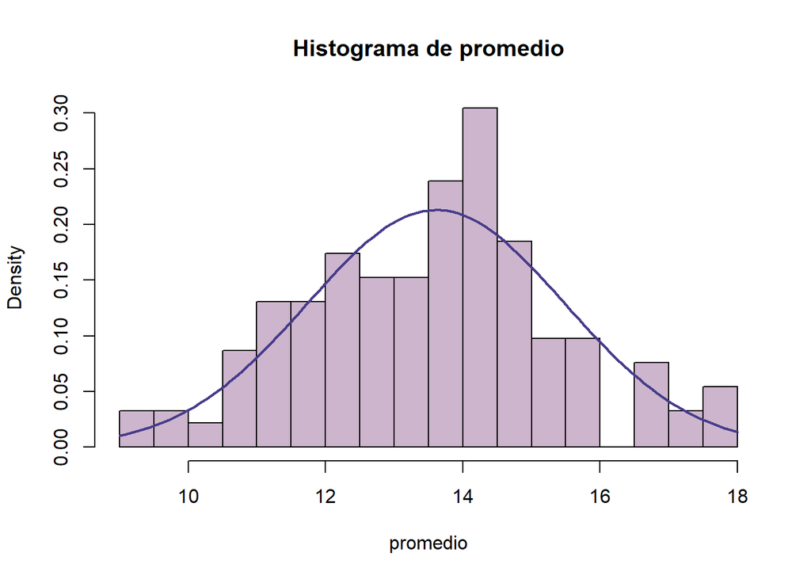

```
## [1] 13.61005
```

```
## [1] 1.872549
```

####caso probabilístico

si tomamos un estudiante que juegen prefieren videojuegos calculamos la probabilidad que su promedio:

1. que apruebe al menos un curso
2. que tenga mas de 15
3. que tenga entre 14 y 16

Solución:

Para poder resolver este caso usaremos los conceptos de una probabilidad de tipo normal, para ello obtendremos los parametros a partir de la desviación estándar y la media de la variable promedio.

la variable aleatoria es: X = nota promedio del alumno que juega videojuego.

X tiene una distribución normal con parámetros μ=13.61005, σ=1.872549

```
## [1] 0.9516297
```

Rta:Entonces la probabilidad de que un alumno que juega videojuegos apruebe almenos un curso es 0.9516297

```
## [1] 0.2289598
```

Rta:Entonces la probabilidad de que un alumno que juega videojuegos tenga una nota promedio mas de 15 es es 0.2289598

```
## [1] 0.3165954
```

.

```
##
##  Shapiro-Wilk normality test
##
## data:  GameSi$promedio
## W = 0.98828, p-value = 0.1325
```

#### analisis del varaiable dinero gastado

[figure not shown]

#### Caso probabilístico

Se observa el gasta de un alumno que juega videojuegos, calculamos la probabilidad de que su gasto anual en soles sea:

1. mayor que 100 soles

```
## [1] 104.3424
```

```
## [1] 93.61319
```

la variable aleatoria es: X = Cantidad de dinero gastado al año por los alumnos.

```
## [1] 0.3835125
```

Rta:Entonces la probabilidad de que un alumno gaste mas de 100 soles al año al jugar videojuegos es: 0.3835125

#concluciones

Por otro lado podemos apreciar que cuando un alumno pasa mas hora jugando tiende a gastar mas dinero al año en los videojuegos, en el análisis que se hizo observamos que aquellos que juegan mas de 10 horas a la semana gastan mas de 100 soles.